# USA Sales 2019-2022: Data Analysis Report

## Description

**The SuperStore dataset comprises a comprehensive sales record from a superstore, containing 9,994 entries across 19 distinct fields. The dataset includes order details, anonymized customer information, product specifics, and financial metrics. This report analyzes various aspects of the dataset to extract meaningful insights.**

# Features

The dataset includes the following columns:

- Order Details: order_id, order_date, ship_date
- Customer Information: customer
- Product Details: manufactory, product_name
- Segmentation: segment, category, subcategory
- Geographical Information: region, zip, city, state, country
- Financial Metrics: discount, profit, quantity, sales, profit_margin

```python
import pandas as pd
import warnings
warnings.filterwarnings('ignore')
import matplotlib.pyplot as plt
import seaborn as sns
# Set the theme for the plots
plt.style.use('dark_background')
```

```python
file_path = r'C:\Users\myloc\Downloads\superstore_dataset 2019-2022.csv'
df = pd.read_csv(file_path)
```

## Explanatory Data Analysis

```python
df.head(10)
```

|  | order_id | order_date | ship_date | customer | manufactory | product_name | segment | category | subcategory | region | zip | city | state | country | discount | profit | quantity | sales | profit_margin |
| --- | --- | --- | --- | --- | --- | --- | --- | --- | --- | --- | --- | --- | --- | --- | --- | --- | --- | --- | --- |
| 0 | US-2020-103800 | 1/3/2019 | 1/7/2019 | Darren Powers | Message Book | Message Book, Wirebound, Four 5 1/2" X 4" Form... | Consumer | Office Supplies | Paper | Central | 77095 | Houston | Texas | United States | 0.2 | 5.5512 | 2 | 16.448 | 0.3375 |
| 1 | US-2020-112326 | 1/4/2019 | 1/8/2019 | Phillina Ober | GBC | GBC Standard Plastic Binding Systems Combs | Home Office | Office Supplies | Binders | Central | 60540 | Naperville | Illinois | United States | 0.8 | -5.4870 | 2 | 3.540 | -1.5500 |
| 2 | US-2020-112326 | 1/4/2019 | 1/8/2019 | Phillina Ober | Avery | Avery 508 | Home Office | Office Supplies | Labels | Central | 60540 | Naperville | Illinois | United States | 0.2 | 4.2717 | 3 | 11.784 | 0.3625 |
| 3 | US-2020-112326 | 1/4/2019 | 1/8/2019 | Phillina Ober | SAFCO | SAFCO Boltless Steel Shelving | Home Office | Office Supplies | Storage | Central | 60540 | Naperville | Illinois | United States | 0.2 | -64.7748 | 3 | 272.736 | -0.2375 |
| 4 | US-2020-141817 | 1/5/2019 | 1/12/2019 | Mick Brown | Avery | Avery Hi-Liter EverBold Pen Style Fluorescent ... | Consumer | Office Supplies | Art | East | 19143 | Philadelphia | Pennsylvania | United States | 0.2 | 4.8840 | 3 | 19.536 | 0.2500 |
| 5 | US-2020-106054 | 1/6/2019 | 1/7/2019 | Jack O'Briant | Dixon | Dixon Prang Watercolor Pencils, 10-Color Set w... | Corporate | Office Supplies | Art | South | 30605 | Athens | Georgia | United States | 0.0 | 5.2398 | 3 | 12.780 | 0.4100 |
| 6 | US-2020-130813 | 1/6/2019 | 1/8/2019 | Lycoris Saunders | Xerox | Xerox 225 | Consumer | Office Supplies | Paper | West | 90049 | Los Angeles | California | United States | 0.0 | 9.3312 | 3 | 19.440 | 0.4800 |
| 7 | US-2020-167199 | 1/6/2019 | 1/10/2019 | Maria Etezadi | Global | Global Deluxe High-Back Manager's Chair | Home Office | Furniture | Chairs | South | 42420 | Henderson | Kentucky | United States | 0.0 | 746.4078 | 9 | 2573.820 | 0.2900 |
| 8 | US-2020-167199 | 1/6/2019 | 1/10/2019 | Maria Etezadi | Rogers | Rogers Handheld Barrel Pencil Sharpener | Home Office | Office Supplies | Art | South | 42420 | Henderson | Kentucky | United States | 0.0 | 1.4796 | 2 | 5.480 | 0.2700 |
| 9 | US-2020-167199 | 1/6/2019 | 1/10/2019 | Maria Etezadi | Ibico | Ibico Hi-Tech Manual Binding System | Home Office | Office Supplies | Binders | South | 42420 | Henderson | Kentucky | United States | 0.0 | 274.4910 | 2 | 609.980 | 0.4500 |

```python
df.tail()
```

|  | order_id | order_date | ship_date | customer | manufactory | product_name | segment | category | subcategory | region | zip | city | state | country | discount | profit | quantity | sales | profit_margin |
| --- | --- | --- | --- | --- | --- | --- | --- | --- | --- | --- | --- | --- | --- | --- | --- | --- | --- | --- | --- |
| 9989 | US-2023-126221 | 12/30/2022 | 1/5/2023 | Chuck Clark | Eureka | Eureka The Boss Plus 12-Amp Hard Box Upright V... | Home Office | Office Supplies | Appliances | Central | 47201 | Columbus | Indiana | United States | 0.0 | 56.5110 | 2 | 209.300 | 0.2700 |
| 9990 | US-2023-143259 | 12/30/2022 | 1/3/2023 | Patrick O'Donnell | Other | Bush Westfield Collection Bookcases, Fully Ass... | Consumer | Furniture | Bookcases | East | 10009 | New York City | New York | United States | 0.2 | 12.1176 | 4 | 323.136 | 0.0375 |
| 9991 | US-2023-143259 | 12/30/2022 | 1/3/2023 | Patrick O'Donnell | Wilson Jones | Wilson Jones Legal Size Ring Binders | Consumer | Office Supplies | Binders | East | 10009 | New York City | New York | United States | 0.2 | 19.7910 | 3 | 52.776 | 0.3750 |
| 9992 | US-2023-143259 | 12/30/2022 | 1/3/2023 | Patrick O'Donnell | Other | Gear Head AU3700S Headset | Consumer | Technology | Phones | East | 10009 | New York City | New York | United States | 0.0 | 2.7279 | 7 | 90.930 | 0.0300 |
| 9993 | US-2023-156720 | 12/30/2022 | 1/3/2023 | Jill Matthias | Other | Bagged Rubber Bands | Consumer | Office Supplies | Fasteners | West | 80538 | Loveland | Colorado | United States | 0.2 | -0.6048 | 3 | 3.024 | -0.2000 |

```python
df.shape
```

```
(9994, 19)
```

```python
df.info()
```

```
<class 'pandas.core.frame.DataFrame'>
RangeIndex: 9994 entries, 0 to 9993
Data columns (total 19 columns):
 #   Column         Non-Null Count  Dtype
---  ------         --------------  -----
 0   order_id       9994 non-null   object
 1   order_date     9994 non-null   object
 2   ship_date      9994 non-null   object
 3   customer       9994 non-null   object
 4   manufactory    9994 non-null   object
 5   product_name   9994 non-null   object
 6   segment        9994 non-null   object
 7   category       9994 non-null   object
 8   subcategory    9994 non-null   object
 9   region         9994 non-null   object
 10  zip            9994 non-null   int64
 11  city           9994 non-null   object
 12  state          9994 non-null   object
 13  country        9994 non-null   object
 14  discount       9994 non-null   float64
 15  profit         9994 non-null   float64
 16  quantity       9994 non-null   int64
 17  sales          9994 non-null   float64
 18  profit_margin  9994 non-null   float64
dtypes: float64(4), int64(2), object(13)
memory usage: 1.4+ MB
```

- clearly there's no null values

```python
df.describe()
```

|  | zip | discount | profit | quantity | sales | profit_margin |
| --- | --- | --- | --- | --- | --- | --- |
| count | 9994.000000 | 9994.000000 | 9994.000000 | 9994.000000 | 9994.000000 | 9994.000000 |
| mean | 55190.371723 | 0.156203 | 28.656896 | 3.789574 | 229.858001 | 0.120314 |
| std | 32063.705315 | 0.206452 | 234.260108 | 2.225110 | 623.245101 | 0.466754 |
| min | 1040.000000 | 0.000000 | -6599.978000 | 1.000000 | 0.444000 | -2.750000 |
| 25% | 23223.000000 | 0.000000 | 1.728750 | 2.000000 | 17.280000 | 0.075000 |
| 50% | 56430.500000 | 0.200000 | 8.666500 | 3.000000 | 54.490000 | 0.270000 |
| 75% | 90008.000000 | 0.200000 | 29.364000 | 5.000000 | 209.940000 | 0.362500 |
| max | 99301.000000 | 0.800000 | 8399.976000 | 14.000000 | 22638.480000 | 0.500000 |

**Data Cleaning**

```python
df.duplicated().sum()
```

```
1
```

```python
df.drop_duplicates(inplace=True)
```

**changing datatypes**

```python
df['order_date'] = pd.to_datetime(df['order_date'])
```

```python
df['ship_date'] = pd.to_datetime(df['ship_date'])
```

**Aggregate Sales and Profit**

```python
print("Total Sales:", round(df['sales'].sum(), 2))
```

```
Total Sales: 2296919.49
```

```python
print("Total Profit:", round(df['profit'].sum(), 2))
```

```
Total Profit: 286409.08
```

**Average Profit Margin**

```python
print("Average Profit Margin:", round(df['profit_margin'].mean(), 2))
```

```
Average Profit Margin: 0.12
```

**Sales and Profit by Category**

```python
category_sales_profit = round(df.groupby('category')[['sales', 'profit']].sum().sort_values(by='sales', ascending=False), 2)
print(category_sales_profit)
```

```
                     sales     profit
category
Technology       836154.03  145454.95
Furniture        741718.42   18463.33
Office Supplies  719047.03  122490.80
```

**Sales and Profit per Region and Category**

```python
category_states_sales_profit = round(df.groupby(['category', 'region'])[['sales', 'profit']].sum().sort_values(by='category', ascending=False), 2)
print(category_states_sales_profit)
```

```
                             sales    profit
category        region
Technology      Central  170416.31  33697.43
                East     264973.98  47462.04
                South    148771.91  19991.83
                West     251991.83  44303.65
Office Supplies Central  167026.42   8879.98
                East     205516.06  41014.58
                South    125651.31  19986.39
                West     220853.25  52609.85
Furniture       Central  163797.16  -2871.05
                East     208009.83   3058.22
                South    117298.68   6771.21
                West     252612.74  11504.95
```

**Top 10 States by Sales**

```python
# Calculate total sales by state, sort in descending order, and take the top 10
top_states_sales = round(df.groupby('state')['sales'].sum().sort_values(ascending=False).head(10), 2)
print("Top 10 States by Sales:\n", top_states_sales)
```

```
Top 10 States by Sales:
 state
California      457687.63
New York        310876.27
Texas           170188.05
Washington      138641.27
Pennsylvania    116511.91
Florida          89473.71
Illinois         80166.10
Ohio             77976.76
Michigan         76269.61
Virginia         70636.72
Name: sales, dtype: float64
```

**Top 10 States by Profit**

```python
top_states_sales = round(df.groupby('state')['profit'].sum().sort_values(ascending=False).head(10), 2)
print("Top 10 States by Profit:\n", top_states_sales)
```

```
Top 10 States by Profit:
 state
California    76381.39
New York      74038.55
Washington    33402.65
Michigan      24463.19
Virginia      18597.95
Indiana       18382.94
Georgia       16250.04
Kentucky      11199.70
Minnesota     10823.19
Delaware       9977.37
Name: profit, dtype: float64
```

**Top 10 States by Discount**

```python
top_states_sales = round(df.groupby('state')['discount'].sum().sort_values(ascending=False).head(10), 2)
print("Top 10 States by discount:\n", top_states_sales)
```

```
Top 10 States by discount:
 state
Texas             364.64
Pennsylvania      192.90
Illinois          191.90
Ohio              152.10
California        145.60
Florida           114.65
North Carolina     70.60
Arizona            68.00
New York           62.40
Colorado           57.60
Name: discount, dtype: float64
```

**Top 10 States by profit_margin**

```python
top_states_sales = round(df.groupby('state')['profit_margin'].sum().sort_values(ascending=False).head(10), 2)
print("Top 10 States by profit_margin:\n", top_states_sales)
```

```
Top 10 States by profit_margin:
 state
California       556.95
New York         336.56
Washington       139.84
Michigan          85.01
Virginia          74.37
Georgia           63.52
Indiana           51.83
Kentucky          46.30
Massachusetts     44.92
New Jersey        43.59
Name: profit_margin, dtype: float64
```

**Top 10 Customers by State, Sales and Profit**

```python
top_customers = round(df.groupby(['customer', 'state'])[['sales', 'profit']].sum().sort_values(by='sales', ascending=False).head(10), 2)
print("Top 10 Customers by Sales and Profit:\n", top_customers)
```

```
Top 10 Customers by Sales and Profit:
                              sales   profit
customer      state
Sean Miller   Florida     23661.23 -1789.73
Tamara Chand  Indiana     18336.74  8762.39
Raymond Buch  Washington  14052.48  6734.47
Tom Ashbrook  New York    13723.50  4599.21
Becky Martin  Texas       10539.90 -1878.79
Hunter Lopez  Delaware    10499.97  5039.99
Sanjit Chand  Minnesota    9900.19  4668.69
Adrian Barton Michigan     9892.74  4946.37
Bill Shonely  New Jersey   9135.19  2381.16
Sanjit Engle  Virginia     8805.04  2825.29
```

**Regional Sales Analysis**

```python
region_sales = round(df.groupby('region')['sales'].sum().sort_values(ascending=False), 2)
print(region_sales)
```

```
region
West       725457.82
East       678499.87
Central    501239.89
South      391721.90
Name: sales, dtype: float64
```

**Correlation Analysis**

```python
correlation = round(df[['discount', 'profit', 'quantity', 'sales', 'profit_margin']].corr(), 2)
print("Correlation Matrix:")
print(correlation)
```

```
Correlation Matrix:
               discount  profit  quantity  sales  profit_margin
discount           1.00   -0.22      0.01  -0.03          -0.86
profit            -0.22    1.00      0.07   0.48           0.22
quantity           0.01    0.07      1.00   0.20          -0.01
sales             -0.03    0.48      0.20   1.00           0.00
profit_margin     -0.86    0.22     -0.01   0.00           1.00
```

**Plot Heatmap of Correlation Matrix**

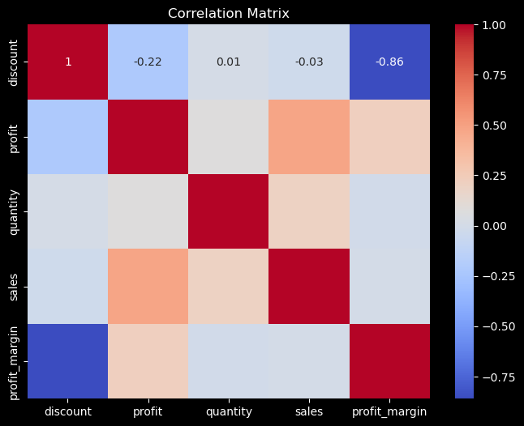

```python
plt.figure(figsize=(8, 6))
sns.heatmap(correlation, annot=True, cmap='coolwarm')
plt.title('Correlation Matrix')
plt.show()
```

## Visualizations

**1. Plot Sales and Profit by Category**

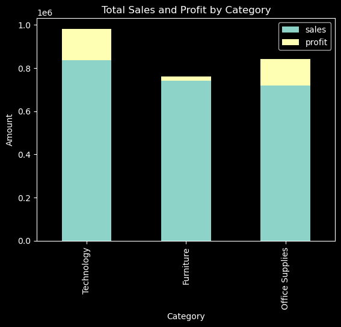

```python
plt.figure(figsize=(10, 6))
category_sales_profit.plot(kind='bar', stacked=True)
plt.title('Total Sales and Profit by Category')
plt.xlabel('Category')
plt.ylabel('Amount')
plt.show()
```

**2.Pie chart for Sales by Category**

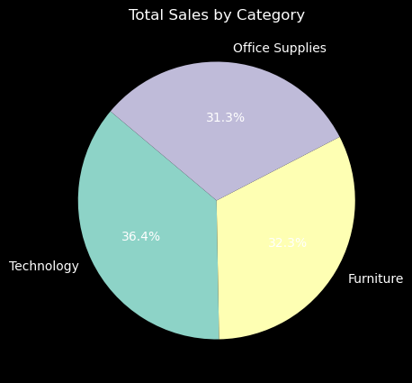

```python
plt.figure(figsize=(10, 5))
plt.pie(category_sales_profit['sales'], labels=category_sales_profit.index, autopct='%1.1f%%', startangle=140)
plt.title('Total Sales by Category')
plt.show()
```

**3.Pie chart for Profit by Category**

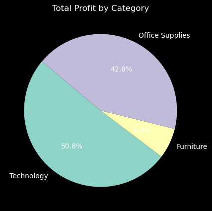

```python
plt.figure(figsize=(10, 5))
plt.pie(category_sales_profit['profit'], labels=category_sales_profit.index, autopct='%1.1f%%', startangle=140)
plt.title('Total Profit by Category')
plt.show()
```

**4. Plot Regional Sales**

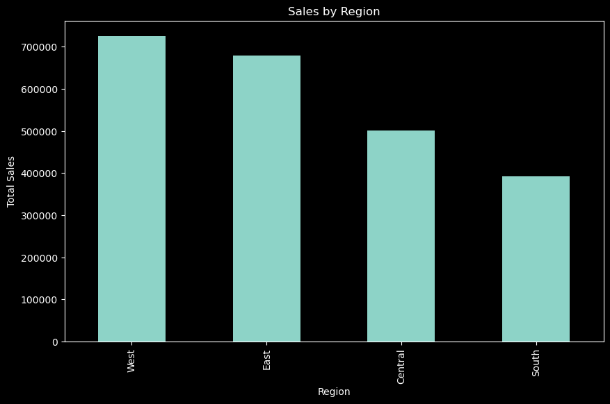

```python
plt.figure(figsize=(10, 6))
region_sales.plot(kind='bar')
plt.title('Sales by Region')
plt.xlabel('Region')
plt.ylabel('Total Sales')
plt.show()
```

**5. Plot Monthly Sales Trend**

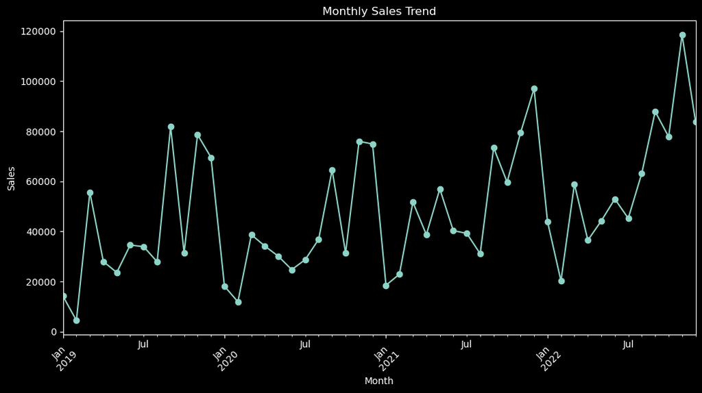

```python
df['month'] = df['order_date'].dt.to_period('M')
monthly_sales = df.groupby('month')['sales'].sum()

# Plot the monthly sales trend
plt.figure(figsize=(12, 6))
monthly_sales.plot(kind='line', marker='o')
plt.title('Monthly Sales Trend')
plt.xlabel('Month')
plt.ylabel('Sales')
plt.xticks(rotation=45)
plt.show()
```

**6. Sales by Category and Subcategory**

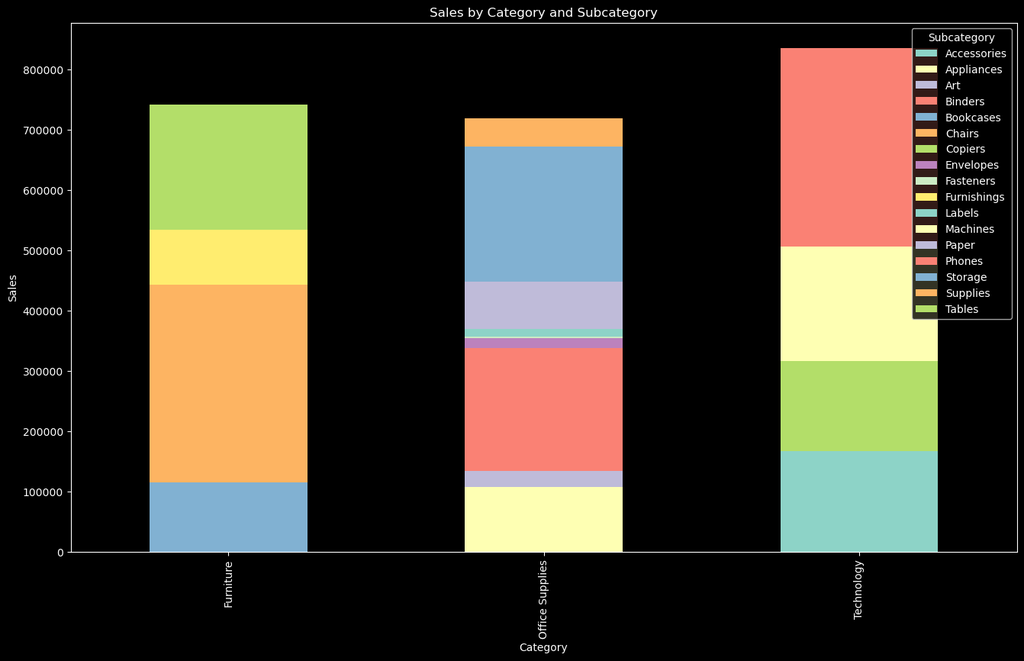

```python
plt.figure(figsize=(16, 9))
category_subcategory_sales = df.groupby(['category', 'subcategory'])['sales'].sum().unstack()

# Plot the stacked bar chart
category_subcategory_sales.plot(kind='bar', stacked=True, figsize=(16, 9))
plt.title('Sales by Category and Subcategory')
plt.xlabel('Category')
plt.ylabel('Sales')
plt.legend(title='Subcategory')
plt.show()
```

**7. Total Quantity Sold by State**

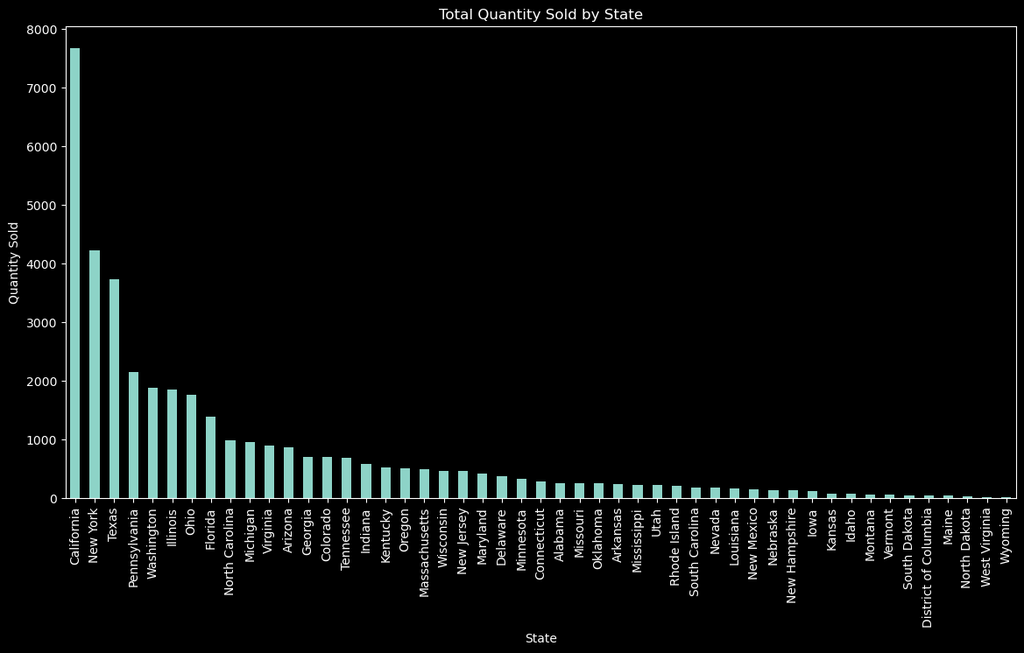

```python
plt.figure(figsize=(14, 7))
state_quantity = df.groupby('state')['quantity'].sum().sort_values(ascending=False)
state_quantity.plot(kind='bar')
plt.title('Total Quantity Sold by State')
plt.xlabel('State')
plt.ylabel('Quantity Sold')
plt.show()
```

**8. Profit Margin by Category**

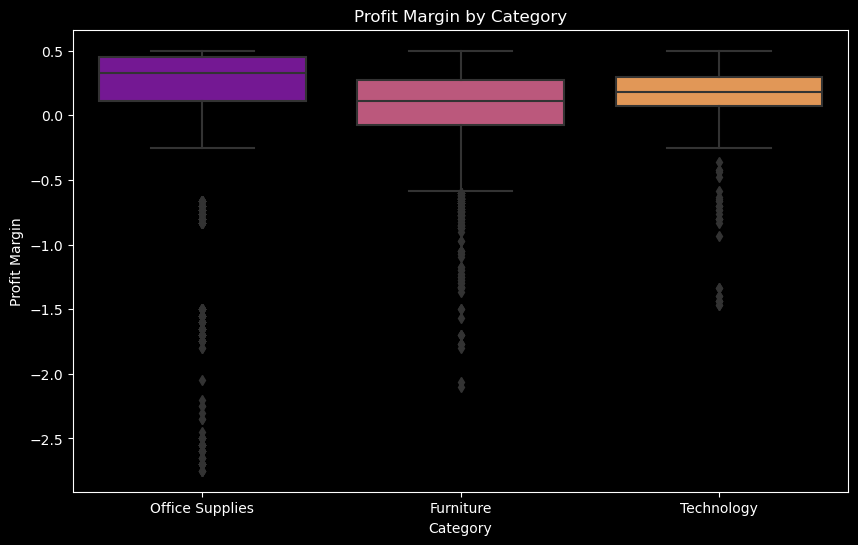

```python
plt.figure(figsize=(10, 6))
sns.boxplot(x='category', y='profit_margin', data=df, palette='plasma')
plt.title('Profit Margin by Category')
plt.xlabel('Category')
plt.ylabel('Profit Margin')
plt.show()
```

**9. Distribution of Discounts**

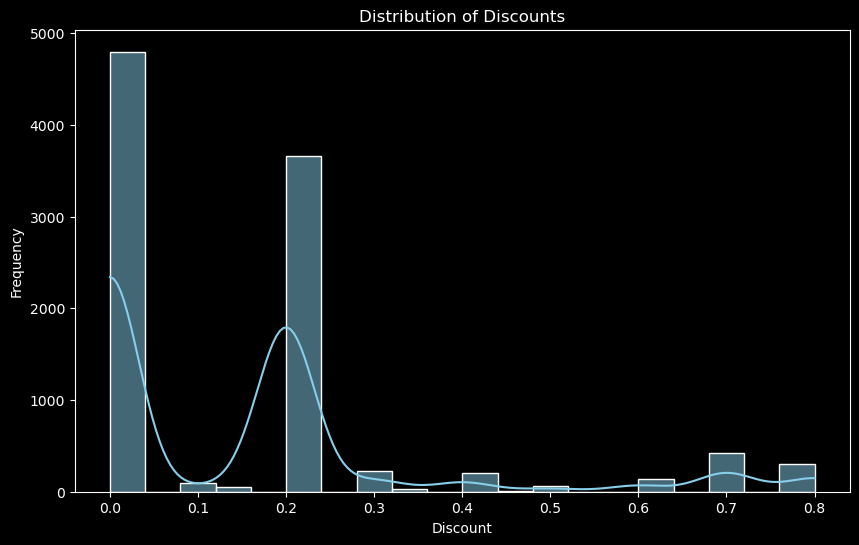

```python
plt.figure(figsize=(10, 6))
sns.histplot(df['discount'], bins=20, kde=True, color='skyblue')
plt.title('Distribution of Discounts')
plt.xlabel('Discount')
plt.ylabel('Frequency')
plt.show()
```

**10. Profit vs. Sales by Category**

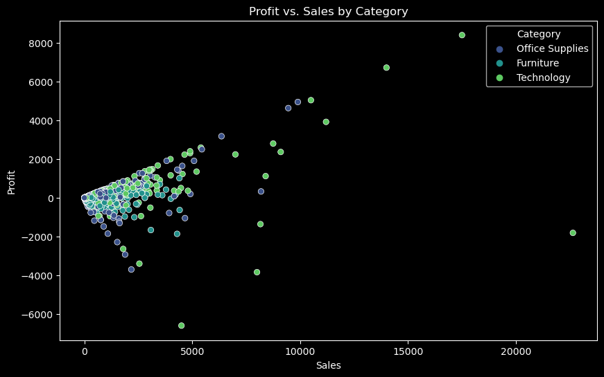

```python
plt.figure(figsize=(10, 6))
sns.scatterplot(x='sales', y='profit', hue='category', data=df, palette='viridis')
plt.title('Profit vs. Sales by Category')
plt.xlabel('Sales')
plt.ylabel('Profit')
plt.legend(title='Category')
plt.show()
```

# Conclusion Report for USA Dataset 2019-2022 Data Analysis

## 2. Profit Margins

- **Profit by Category**: The data categorizes products by profitability, allowing us to pinpoint high-margin products. This insight aids in strategic planning, such as emphasizing high-profit products in marketing.
- **Profitability by Region**: Regional profit analysis highlights areas where the business performs exceptionally well or underperforms, allowing targeted adjustments in sales strategies or operational costs.

## 3. Regional Performance Analysis

- **Top-Performing Regions**: Identifying the highest revenue-generating regions helps prioritize resources. This section examines the geographical distribution of sales, providing a clear picture of where demand is highest.
- **Region-Specific Challenges**: Low-performance areas may signal logistical, competitive, or demographic issues that require tailored strategies to improve profitability.

## 4. Product Category Analysis

- **High-Demand Categories**: Specific categories or sub-categories that consistently show high demand are highlighted. This insight supports decisions on stock levels, pricing, and promotions for popular items.
- **Low-Demand Categories**: Identifying products with lower demand helps in managing inventory, reducing overstock, and reconsidering future investments in these products.

## 7. Impact of Discounts

# Final Recommendations

Based on the above insights, the following recommendations are proposed:

- **Focus on High-Profit Categories**: Increase marketing efforts and inventory for high-demand, high-profit products.
- **Region-Specific Strategies**: Tailor strategies for low-performing regions to improve profitability or reduce operational costs.
- **Optimize Discounts**: Use discounts selectively to balance increased sales with profit margins, focusing on times and products where discounts drive the most value.
- **Improve Customer Retention**: Develop loyalty programs for high-value customers, focusing on retaining and increasing their lifetime value.

This comprehensive analysis supports data-driven decision-making and strategic planning to enhance sales performance, improve customer satisfaction, and maximize profitability.